# STAT509-001-HW5-Xinye Xu

## Q2

1. Carry out a preliminary data analysis, including skewness, kurtosis, correlational anal- ysis and scatter diagrams, and provide a summary discussion of your findings.

```r
library(moments)
library(Ecdat)
library(fGarch)
library(copula)
library(fCopulae)
Data = read.csv("Data/midcapD.csv", header=TRUE)
Mid = Data[,c(5,6,7)]

nyb = Mid$NYB
altr = Mid$ALTR
aph = Mid$APH
apply(Mid, 2, function (x) c(skewness(x),kurtosis(x)) )
```

```
##             NYB      ALTR       APH
## [1,] -0.3481627 0.2738863 0.4139656
## [2,]  3.6611891 1.3195310 4.0401221
```

```r
signif( cor(Mid), digits=3 )
```

```
##         NYB  ALTR    APH
## NYB  1.0000 0.116 0.0755
## ALTR 0.1160 1.000 0.3810
## APH  0.0755 0.381 1.0000
```

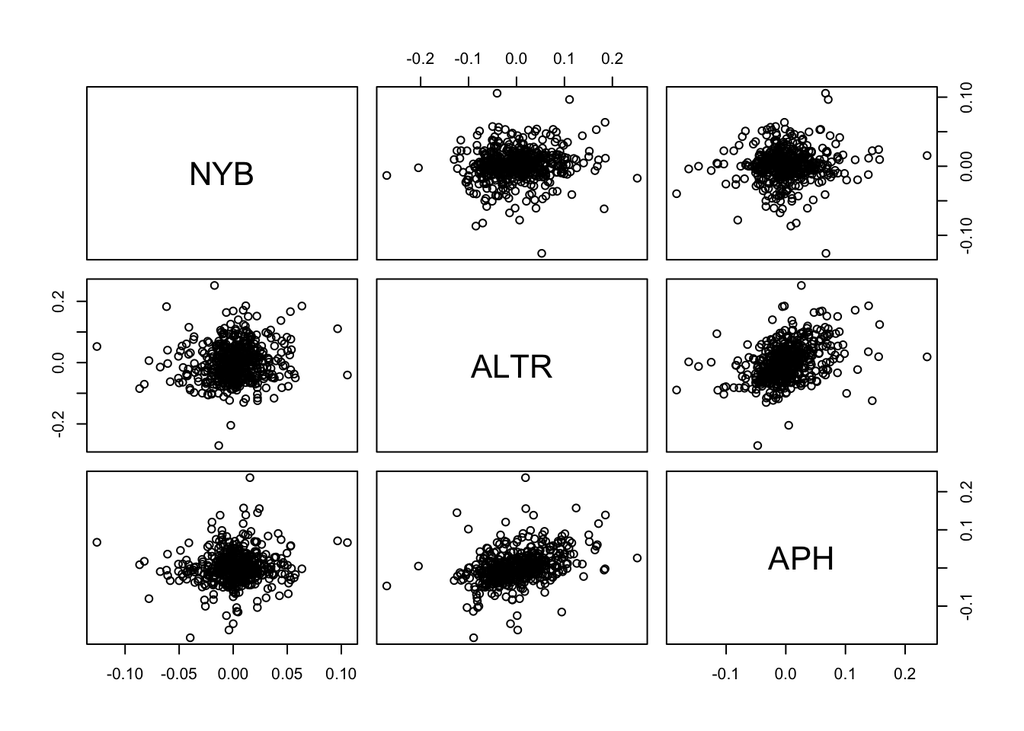

```r
pairs(Mid)
```

2. Carry out a fitting of a multivariate normal distribution to the returns and carry out diagnostic plots – univariate QQ plots for each.

Calculate the sample mean and sample covariance matrix. From the QQ plots, distributions of NYB return and APH return have significantly heavier tails than normal. ALTR seems to be more linear in the line, meaning it is much close to normal distribution.

```r
library(timeSeries)
library(mnormt)
signif(colMeans(Mid), digits=3)
```

```
##     NYB    ALTR     APH
## 0.00169 0.00149 0.00161
```

```r
signif(cov(Mid), digits=3)
```

```
##           NYB     ALTR      APH
## NYB  5.41e-04 0.000162 7.39e-05
## ALTR 1.62e-04 0.003620 9.67e-04
## APH  7.39e-05 0.000967 1.77e-03
```

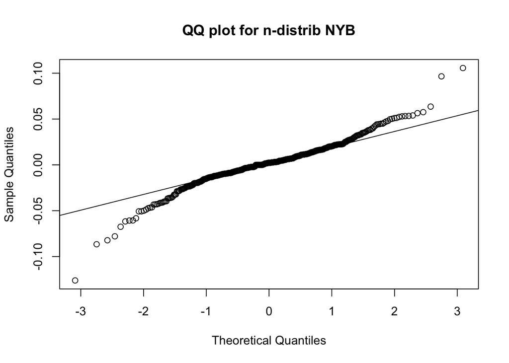

```r
qqnorm(nyb, main="QQ plot for n-distrib NYB")
qqline(nyb)
```

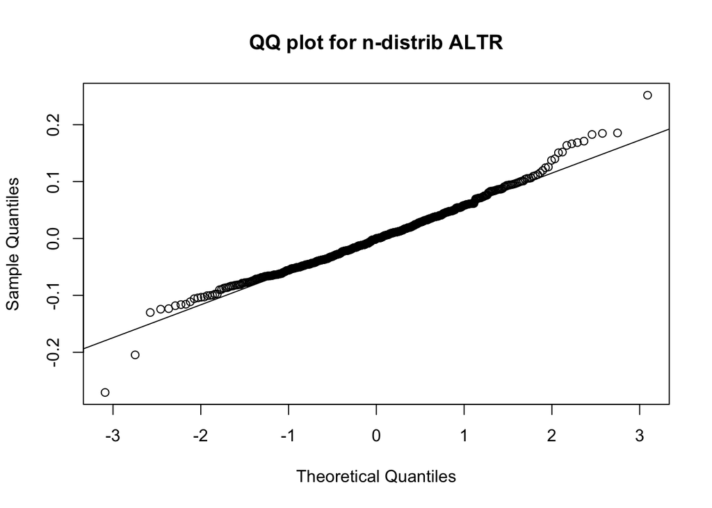

```r
qqnorm(altr, main="QQ plot for n-distrib ALTR")
qqline(altr)
```

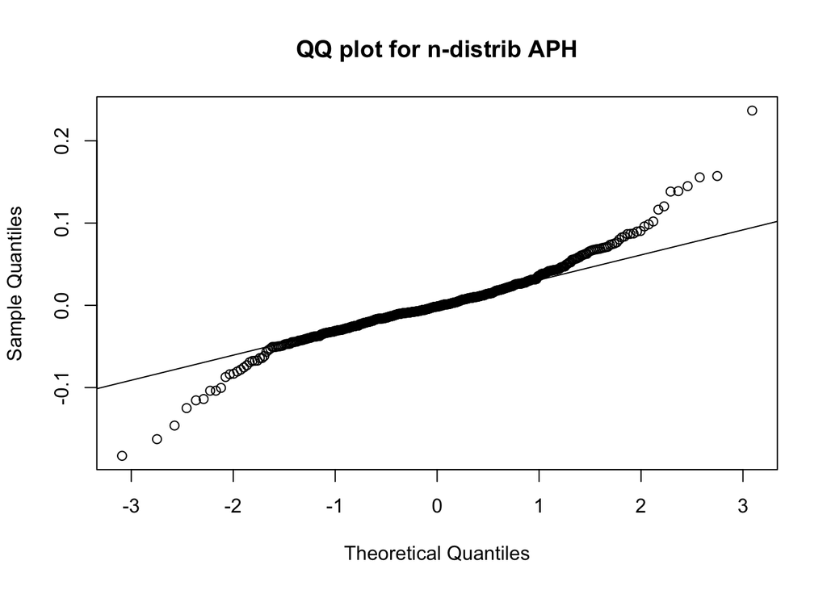

```r
qqnorm(aph, main="QQ plot for n-distrib APH")
qqline(aph)
```

3. Same as (b), but now use a multivariate t distribution – also derive a confidence interval for the degrees of freedom via the method of profile likelihood.

From the first plot, we can notice that MLE happens around 4.5. We also derive the confidence interval for the degree is [3.665, 6.025] Notice from the plots, NYB and APH have heavier tails than T distribution (nu=4.64). ALTR has a lighter tail than T distribution, which follows the above conclusion that it is much closed to normal.

```r
# Chapter 6, slide page 41
library(MASS)
```

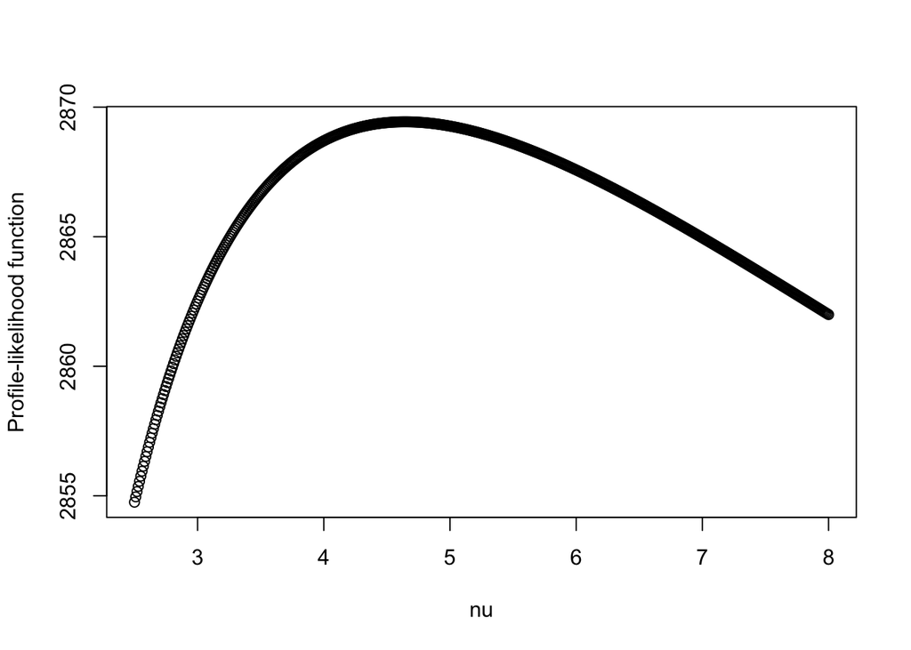

```r
df = seq(2.5, 8, 0.01)
n = length(df)
loglik_max = rep(0,n)
for (i in 1:n){
  fit = cov.trob(Mid, nu=df[i])
  mu = as.vector(fit$center)
  sigma = matrix(fit$cov, nrow=3)
  loglik_max[i] = sum(log(dmt(Mid, mean=fit$center, S=fit$cov, df=df[i])))}
plot(df, loglik_max, xlab='nu', ylab='Profile-likelihood function')
```

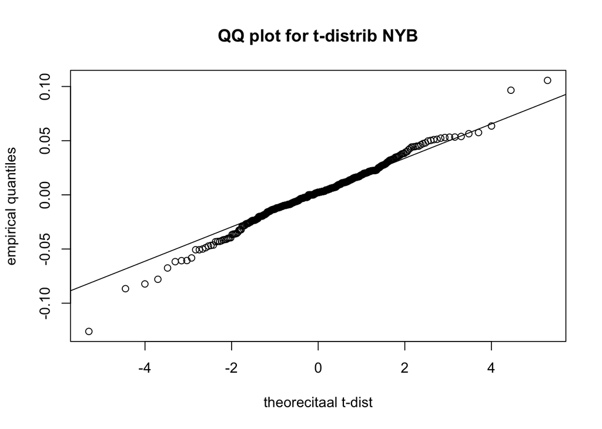

```r
nuest = df[which.max(loglik_max)]
fitfinal = cov.trob(Mid, nu=nuest)
muest = fitfinal$center
lambdaest = fitfinal$cov

N = length(Mid[,1])
quantv = (1/(N+1))*seq(1,N,1)
qqplot(qt(quantv, nuest), sort(Mid[,1]), main='QQ plot for t-distrib NYB', xlab='theorecitaal t-dist', ylab='empirical quantiles')
abline(lm(quantile(Mid[,1], c(.25,.75))~qt(c(.25,.75), nuest )))
```

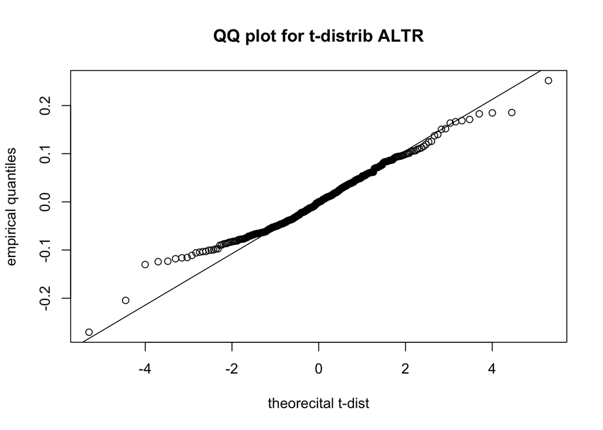

```r
qqplot(qt(quantv, nuest), sort(Mid[,2]), main='QQ plot for t-distrib ALTR', xlab='theorecital t-dist', ylab='empirical quantiles')
abline(lm(quantile(Mid[,2], c(.25,.75))~qt(c(.25,.75), nuest )))
```

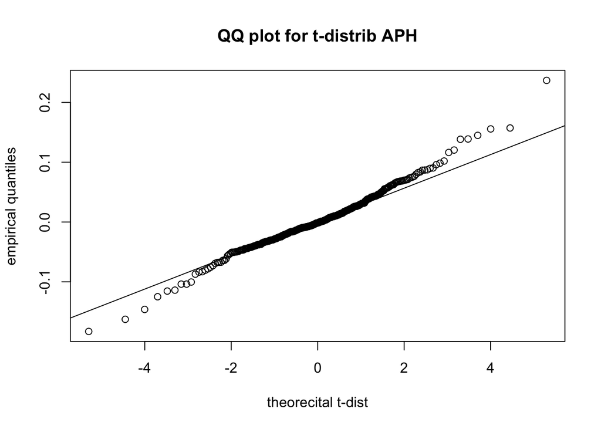

```r
qqplot(qt(quantv, nuest), sort(Mid[,3]), main='QQ plot for t-distrib APH', xlab='theorecital t-dist', ylab='empirical quantiles')
abline(lm(quantile(Mid[,3], c(.25,.75))~qt(c(.25,.75), nuest )))
```

```r
ka_value = (1/2)*qchisq(0.95, 1)
CI = signif(max(loglik_max) - ka_value ,digits = 6)
CI
```

```
## [1] 2867.51
```

```r
CI_ind = which(CI == signif(loglik_max,digits = 6))
CI_ind #  117 354
```

```
## [1] 117 354
```

```r
0.5 * (df[117] + df[118])
```

```
## [1] 3.665
```

```r
0.5 * (df[353] + df[354])
```

```
## [1] 6.025
```

4. Based on results in (b) and (c), which model do you prefer and why. Compare the two models of multivariate normal vs. multivariate t using the AIC criteria.

AIC for multivariate normal vs. multivariate t is -5553.348 -5718.868 respectively,

```r
sampmean = signif(colMeans(Mid),digits = 3)
sampcov = signif(cov(Mid),digits = 4)
logliken_max = sum(log(dmnorm(Mid,mean=sampmean,sampcov)))
logliket_max = loglik_max[which.max(loglik_max)]
AIC_mnorm = -2*logliken_max + 2*(3+6)
AIC_mt = -2*logliket_max + 2*(3+6+1)
c(AIC_mnorm,AIC_mt)
```

```
## [1] -5553.348 -5718.868
```

## Q3

1. Based on the estimated multivariate model in 2-(b), derive the optimal portfolio between the 3 stocks that minimizes volatility.

optimal portfolio for these 3 stocks are weighted as 0.77042794, 0.03385205 and 0.19572001, and then the minimal vol = 0.02089274.

```r
COV = cov(Mid)
e = c(1,1,1)
portfolio = ( ginv(COV) %*% e ) / as.double(t(e) %*% ginv(COV) %*% e )
portfolio
```

```
##            [,1]
## [1,] 0.77042794
## [2,] 0.03385205
## [3,] 0.19572001
```

```r
sqrt(t(portfolio) %*% COV %*% portfolio)
```

```
##            [,1]
## [1,] 0.02089274
```

2. Based on the estimated multivariate model in 2-(b), derive the optimal portfolio be- tween the 3 stocks that minimizes relative VaR at q = .002.

```r
weigh = matrix(0, 101*101,3)
count = 1
for (i in 0:100){
  for (j in 0:100){
    weigh[count, 1] = i/100
    weigh[count, 2] = j/100
    weigh[count, 3] = 1 - i/100 - j/100
    count = count + 1
  }
}

# min VaR - multi-Normal
n = length(weigh[,1])
VaR_v = rep(0, n)
MU = as.vector(colMeans(Mid))
COV = as.matrix(cov(Mid))
for (i in 1:n){
  w_i = weigh[i,]
  P_mean = t(weigh[i,]) %*% MU
  P_sd = sqrt( t(weigh[i,]) %*% COV %*% weigh[i,] )
  VaR_v[i] = -qnorm(.002,P_mean,P_sd)
}

weigh[which.min(VaR_v),]
```

```
## [1] 0.77 0.03 0.20
```

```r
VaR_v[which.min(VaR_v)]
```

```
## [1] 0.05847047
```

3. Based on the estimated multivariate model in 2-(c), derive the optimal portfolio between the 3 stocks that minimizes volatility.

Optimal portfolio for these 3 stocks are weighted as 0.765709430, 0.004300497 and 0.229990073, and then the minimal vol = 0.01564688

```r
fit = cov.trob(Mid, nu=4.64)
COV = fit$cov
e = c(1,1,1)
portfolio_n = ( ginv(COV) %*% e ) / as.double(t(e) %*% ginv(COV) %*% e )
portfolio_n
```

```
##             [,1]
## [1,] 0.765709430
## [2,] 0.004300497
## [3,] 0.229990073
```

```r
sqrt(t(portfolio_n) %*% COV %*% portfolio_n)
```

```
##            [,1]
## [1,] 0.01564688
```

4. Based on the estimated multivariate model in 2-(c), derive the optimal portfolio between the 3 stocks that minimizes relative VaR at q = .002.

Best weights are 0.77 0.00 0.23 for each stock, and then the minimal VaR = 0.08121188 * Price

```r
fit = cov.trob(Mid, nu=4.64)
MU = as.vector(fit$center)
COV = as.matrix(fit$cov)

for (i in 1:n){
  w_i = weigh[i,]
  P_mean = t(weigh[i,]) %*% MU
  P_scale = sqrt( t(weigh[i,]) %*% COV %*% weigh[i,] )
  VaR_v[i] = -( P_scale*qt(.002, 4.64) + P_mean )
}

weigh[which.min(VaR_v),]
```

```
## [1] 0.77 0.00 0.23
```

```r
VaR_v[which.min(VaR_v)]
```

```
## [1] 0.08121188
```